# Serie de tiempo cáncer de Piel en Antofagasta

#### Variables en la base de datos.

- TUMOURID: Identificación del tumor.
- NOCASO: Número del caso (1 caso puede tener uno o más tumores).
- FECNAC: Fecha nacimiento en formato YYYYMMDD (variable numérica).
- EDAD: Edad en años a la fecha del diagnóstico.
- SEXO:
  - 1=Hombre,
  - 2=Mujeres.
- REGCOM: Código comunas:
  - 2101=Antofagasta;
  - 2201=Calama;
  - 2301=Tocopilla.
- FECDIAG: Fecha de diagnóstico del tumor en formato YYYYMMDD (variable numérica), “20030101 - 20151231”.
- TOP: Código topográfico del tumor en formato CIE-O.
- MORF: Código morfológico CIE-O.
- MORF_GRUPO (PIEL):
  - 1=Neoplasias de células escamosas;
  - 2=Neoplasias de células basales;
  - 3=Otras Morfologías
- COMP: Comportamiento del tumor:
  - 3=Maligno.
- GRA: Grado de diferenciación del tumor:
  - 1=Bien diferenciado;
  - 2= Moderadamente Diferenciado;
  - 3=Poco Diferenciado;
  - 4=Anaplásico;
  - 5=Células T;
  - 6=Células B;
  - 7=Célula Nula;
  - 8=Células NK;
  - 9=Desconocido.
- EXT: Grado de extensión del tumor:
  - 0=In situ;
  - 1=Localizado;
  - 2=Regional;
  - 3=Metástasis;
  - 9=Desconocido.
- BASE: Base diagnóstico:
  - 0=Solo Certificado de defunción;
  - 1=Clínico;
  - 2=Investigación clínica;
  - 4=Bioquímica o Inmunología;
  - 5=Citología;
  - 6=Histología de metástasis;
  - 7=Histología de sitio primario;
  - 9=Desconocido.
- C10: Código CIE10.
- PMSEC: Secuencia de tumores primarios.
- PMTOT: Número total de tumores primarios.
- FUE1: Fuente.
- RUT: Rut del caso.

```r
table(bd_$MORF)
```

```
##
## 8000 8004 8010 8011 8030 8050 8051 8070 8071 8072 8074 8075 8076 8082 8083 8084
##   26    2   31    1    1    1   12  747  101   16    1    1   10    1    7    3
## 8090 8091 8092 8093 8094 8095 8097 8098 8102 8140 8230 8246 8247 8310 8401 8410
## 1959   93   42    2  150    1  710    6    1    7    9    2   13    1    1    9
## 8430 8480 8560 8574 8832 8833 8980
##    1    2    1    1   12    1    1
```

# Estadística descriptiva

### Número de casos por sexo

```
##
## Hombres Mujeres
##    2058    1928
```

### Proporción de casos por sexo

```
##
## Hombres Mujeres
##   51.63   48.37
```

### Casos por comuna

```
##
##                 Afta           Mejillones         Sierra Gorda
##                 3094                   72                    4
##               Taltal               Calama              Ollagüe
##                   46                  498                    0
## San Pedro de Atacama            Tocopilla          MAría Elena
##                   14                  210                   48
##                  Sum
##                 3986
```

### Proporción de casos por comuna

```
##
##                 Afta           Mejillones         Sierra Gorda
##                   78                    2                    0
##               Taltal               Calama              Ollagüe
##                    1                   12                    0
## San Pedro de Atacama            Tocopilla          MAría Elena
##                    0                    5                    1
```

### Casos en Antofagasta, Calama y Tocopilla

```
##
##      Afta    Calama Tocopilla
##      3094       498       210
```

### Proporción de casos en Antofagasta, Calama y Tocopilla

```
##
##      Afta    Calama Tocopilla
##     81.38     13.10      5.52
```

### Casos según morfología

```
##
## Neoplasias de células escamosas   Neoplasias de células basales
##                             900                            2964
##               Otras morfologías
##                             122
```

### Proporción de casos según morfología

```
##
## Neoplasias de células escamosas   Neoplasias de células basales
##                            22.6                            74.4
##               Otras morfologías
##                             3.1
```

### Casos según diferenciacion tumores

```
##
##           Bien Diferenciado Moderadamente Diferenciados
##                         304                         453
##           Poco Diferenciado                  Anaplásico
##                         121                           3
##                 Desconocido
##                        3105
```

### Proporción de casos según diferenciación

```
##
##           Bien Diferenciado Moderadamente Diferenciados
##                        7.63                       11.36
##           Poco Diferenciado                  Anaplásico
##                        3.04                        0.08
##                 Desconocido
##                       77.90
```

### Casos según extensión tumoral

```
##
##  Localizado    Regional  Metástasis Desconocido
##        3776          39          40         131
```

### Proporción de casos según extensión tumoral

```
##
##  Localizado    Regional  Metástasis Desconocido
##       94.73        0.98        1.00        3.29
```

### Casos según base diagnóstico

```
##
##                     Solo DCO                      Clínica
##                            7                            9
##            Histología de MTS Histología de sitio primario
##                           11                         3959
```

### Proporción de casos según base diagnóstico

```
##
##                     Solo DCO                      Clínica
##                         0.18                         0.23
##            Histología de MTS Histología de sitio primario
##                         0.28                        99.32
```

### Edad

| Mínimo | Máximo | Rango | Qu_25 | Qu_50 | Qu_75 | Media | Mediana | Varianza | Desv_Estándar | CV |
| --- | --- | --- | --- | --- | --- | --- | --- | --- | --- | --- |
| 13 | 99 | 86 | 54 | 65 | 75 | 64.5733 | 65 | 196.5273 | 14.0188 | 21.7099 |

### Histrograma edad

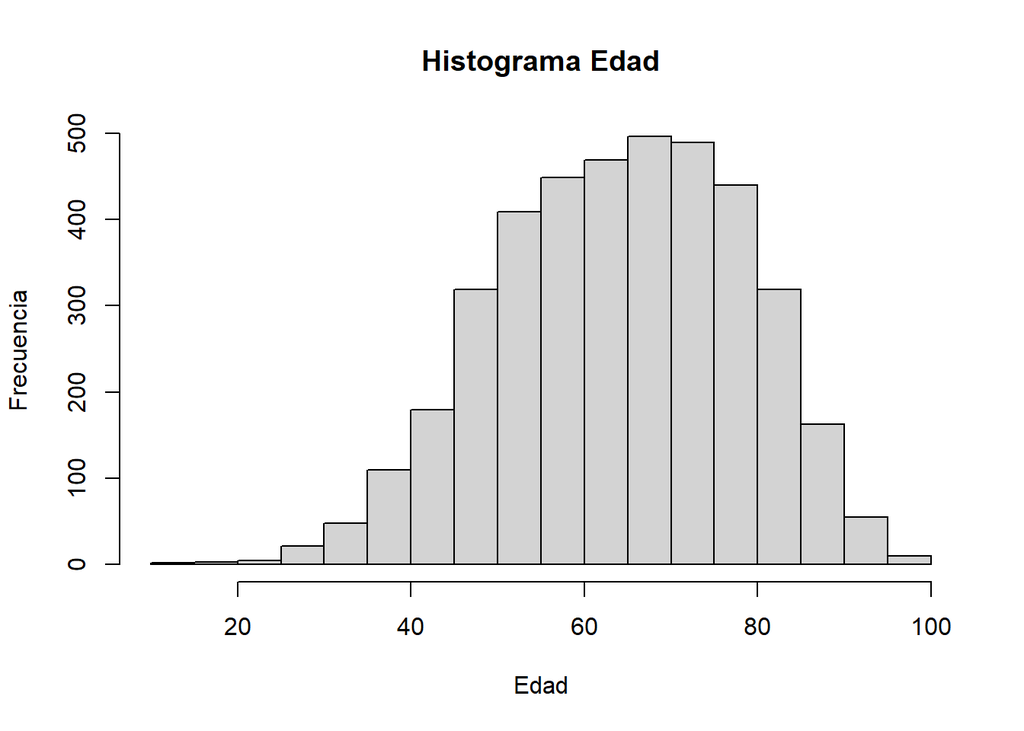

### Gráfico de densidad edad

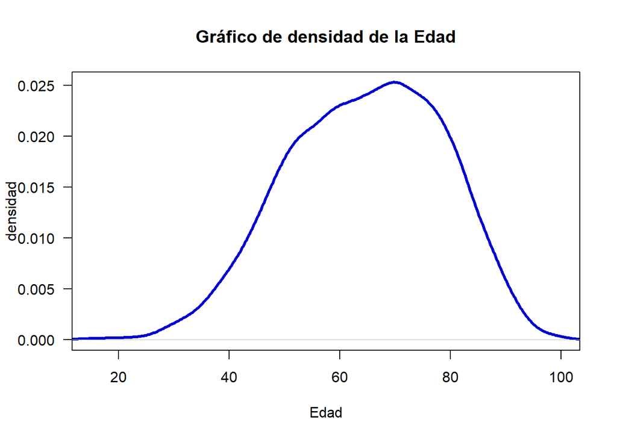

### Normal QQ

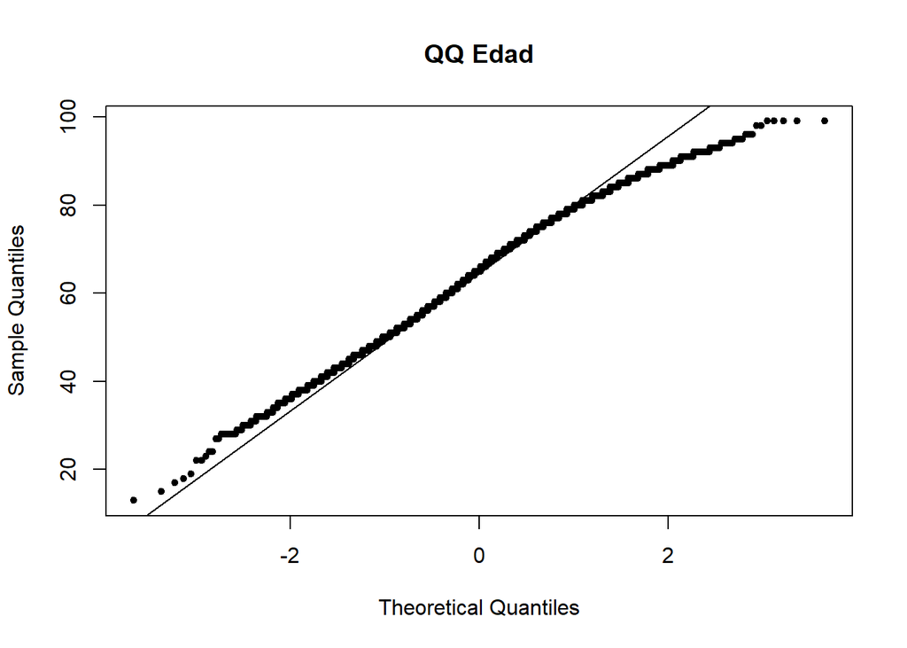

### Test de normalidad de Shapiro-Wilk

```
##
##  Shapiro-Wilk normality test
##
## data:  bd_$EDAD
## W = 0.99082, p-value = 2.153e-15
```

## Estadística descriptiva Bivariada

### Número de casos por sexo en las comunas de Antofagasta, Calama y Tocopilla

```
##
##               Hombres Mujeres  Sum
##   Antofagasta    1586    1508 3094
##   Calama          271     227  498
##   Tocopilla        96     114  210
##   Sum            1953    1849 3802
```

### Proporción de casos por sexo en las comunas de Antofagasta, Calama y Tocopilla

```
##
##               Hombres Mujeres    Sum
##   Antofagasta   51.26   48.74 100.00
##   Calama        54.42   45.58 100.00
##   Tocopilla     45.71   54.29 100.00
```

### Número de casos por sexo y morfología

```
##
##                                   Hombres Mujeres  Sum
##   Neoplasias de células escamosas     543     357  900
##   Neoplasias de células basales      1446    1518 2964
##   Otras morfologías                    69      53  122
##   Sum                                2058    1928 3986
```

### Proporción de casos por sexo y morfología

```
##
##                                   Hombres Mujeres    Sum
##   Neoplasias de células escamosas   60.33   39.67 100.00
##   Neoplasias de células basales     48.79   51.21 100.00
##   Otras morfologías                 56.56   43.44 100.00
```

### Número de casos por sexo y extensión tumoral

```
##
##               Hombres Mujeres  Sum
##   Localizado     1939    1837 3776
##   Regional         19      20   39
##   Metástasis       25      15   40
##   Desconocido      75      56  131
##   Sum            2058    1928 3986
```

### Proporción de casos por sexo y extensión tumoral

```
##
##               Hombres Mujeres    Sum
##   Localizado    51.35   48.65 100.00
##   Regional      48.72   51.28 100.00
##   Metástasis    62.50   37.50 100.00
##   Desconocido   57.25   42.75 100.00
```

### Número de casos por sexo y base diagnóstica

```
##
##                                Hombres Mujeres  Sum
##   Solo DCO                           3       4    7
##   Clínico                            5       4    9
##   Histología de Metástasis           6       5   11
##   Histología de sitio primario    2044    1915 3959
##   Sum                             2058    1928 3986
```

### Proporción de casos por sexo y base diagnóstica

```
##
##                                Hombres Mujeres    Sum
##   Solo DCO                       42.86   57.14 100.00
##   Clínico                        55.56   44.44 100.00
##   Histología de Metástasis       54.55   45.45 100.00
##   Histología de sitio primario   51.63   48.37 100.00
```

### Número de casos por Morfología y base diagnóstica

```
##
##                                   Solo DCO Clínico Histología de Metástasis
##   Neoplasias de células escamosas        0       0                        7
##   Neoplasias de células basales          0       0                        3
##   Otras morfologías                      7       9                        1
##   Sum                                    7       9                       11
##
##                                   Histología de sitio primario  Sum
##   Neoplasias de células escamosas                          893  900
##   Neoplasias de células basales                           2961 2964
##   Otras morfologías                                        105  122
##   Sum                                                     3959 3986
```

### Proporción de casos por Morfología y base diagnóstica

```
##
##                                   Solo DCO Clínico Histología de Metástasis
##   Neoplasias de células escamosas     0.00    0.00                     0.78
##   Neoplasias de células basales       0.00    0.00                     0.10
##   Otras morfologías                   5.74    7.38                     0.82
##
##                                   Histología de sitio primario    Sum
##   Neoplasias de células escamosas                        99.22 100.00
##   Neoplasias de células basales                          99.90 100.00
##   Otras morfologías                                      86.07 100.00
```

### Número de casos por Morfología y Extensión

```
##
##                                   Localizado Regional Metástasis Desconocido
##   Neoplasias de células escamosas        842       12         21          25
##   Neoplasias de células basales         2848       20          5          91
##   Otras morfologías                       86        7         14          15
##   Sum                                   3776       39         40         131
##
##                                    Sum
##   Neoplasias de células escamosas  900
##   Neoplasias de células basales   2964
##   Otras morfologías                122
##   Sum                             3986
```

### Proporción de casos por Morfología y Extensión

```
##
##                                   Localizado Regional Metástasis Desconocido
##   Neoplasias de células escamosas      93.56     1.33       2.33        2.78
##   Neoplasias de células basales        96.09     0.67       0.17        3.07
##   Otras morfologías                    70.49     5.74      11.48       12.30
##
##                                      Sum
##   Neoplasias de células escamosas 100.00
##   Neoplasias de células basales   100.00
##   Otras morfologías               100.00
```

### Número de casos por Morfología y comuna

```
##
##                                   Antofagasta Calama Tocopilla  Sum
##   Neoplasias de células escamosas         711     92        54  857
##   Neoplasias de células basales          2292    387       148 2827
##   Otras morfologías                        91     19         8  118
##   Sum                                    3094    498       210 3802
```

### Proporción de casos por Morfología y comuna, por filas

```
##
##                                   Antofagasta Calama Tocopilla    Sum
##   Neoplasias de células escamosas       82.96  10.74      6.30 100.00
##   Neoplasias de células basales         81.08  13.69      5.24 100.00
##   Otras morfologías                     77.12  16.10      6.78 100.00
```

### Proporción de casos por Morfología y comuna, por columnas

```
##
##                                   Antofagasta Calama Tocopilla
##   Neoplasias de células escamosas       22.98  18.47     25.71
##   Neoplasias de células basales         74.08  77.71     70.48
##   Otras morfologías                      2.94   3.82      3.81
##   Sum                                  100.00 100.00    100.00
```

### Número de casos por Extensión y comuna

```
##
##               Antofagasta Calama Tocopilla  Sum
##   Localizado         2927    467       202 3596
##   Regional             31      6         1   38
##   Metástasis           31      6         3   40
##   Desconocido         105     19         4  128
##   Sum                3094    498       210 3802
```

### Proporcion de casos por Extensión y comuna, filas

```
##
##               Antofagasta Calama Tocopilla    Sum
##   Localizado        81.40  12.99      5.62 100.00
##   Regional          81.58  15.79      2.63 100.00
##   Metástasis        77.50  15.00      7.50 100.00
##   Desconocido       82.03  14.84      3.12 100.00
```

### Proporción de casos por Extensión y comuna, columnas

```
##
##               Antofagasta Calama Tocopilla
##   Localizado        94.60  93.78     96.19
##   Regional           1.00   1.20      0.48
##   Metástasis         1.00   1.20      1.43
##   Desconocido        3.39   3.82      1.90
##   Sum              100.00 100.00    100.00
```

### Número de casos por Extensión y Base diagnóstica

```
##
##               Solo DCO Clínico Histología de Metástasis
##   Localizado         0       3                        4
##   Regional           0       2                        1
##   Metástasis         1       3                        6
##   Desconocido        6       1                        0
##   Sum                7       9                       11
##
##               Histología de sitio primario  Sum
##   Localizado                          3769 3776
##   Regional                              36   39
##   Metástasis                            30   40
##   Desconocido                          124  131
##   Sum                                 3959 3986
```

### Proporción de casos por Extensión y Base diagnóstica, filas

```
##
##               Solo DCO Clínico Histología de Metástasis
##   Localizado      0.00    0.08                     0.11
##   Regional        0.00    5.13                     2.56
##   Metástasis      2.50    7.50                    15.00
##   Desconocido     4.58    0.76                     0.00
##
##               Histología de sitio primario    Sum
##   Localizado                         99.81 100.00
##   Regional                           92.31 100.00
##   Metástasis                         75.00 100.00
##   Desconocido                        94.66 100.00
```

### Proporción de casos por Extensión y Base diagnóstica, columnas

```
##
##               Solo DCO Clínico Histología de Metástasis
##   Localizado      0.00   33.33                    36.36
##   Regional        0.00   22.22                     9.09
##   Metástasis     14.29   33.33                    54.55
##   Desconocido    85.71   11.11                     0.00
##   Sum           100.00  100.00                   100.00
##
##               Histología de sitio primario
##   Localizado                         95.20
##   Regional                            0.91
##   Metástasis                          0.76
##   Desconocido                         3.13
##   Sum                               100.00
```

### Número de casos por Base diagnóstica y comuna

```
##
##                                Antofagasta Calama Tocopilla  Sum
##   Solo DCO                               4      2         1    7
##   Clínico                                7      1         1    9
##   Histología de Metástasis               6      5         0   11
##   Histología de sitio primario        3077    490       208 3775
##   Sum                                 3094    498       210 3802
```

### Proporción de casos por Base diagnóstica y comuna, filas

```
##
##                                Antofagasta Calama Tocopilla    Sum
##   Solo DCO                           57.14  28.57     14.29 100.00
##   Clínico                            77.78  11.11     11.11 100.00
##   Histología de Metástasis           54.55  45.45      0.00 100.00
##   Histología de sitio primario       81.51  12.98      5.51 100.00
```

### Proporción de casos por Base diagnóstica y comuna, columnas

```
##
##                                Antofagasta Calama Tocopilla
##   Solo DCO                            0.13   0.40      0.48
##   Clínico                             0.23   0.20      0.48
##   Histología de Metástasis            0.19   1.00      0.00
##   Histología de sitio primario       99.45  98.39     99.05
##   Sum                               100.00 100.00    100.00
```

### Edad - Sexo

#### Boxplot edad vs sexo

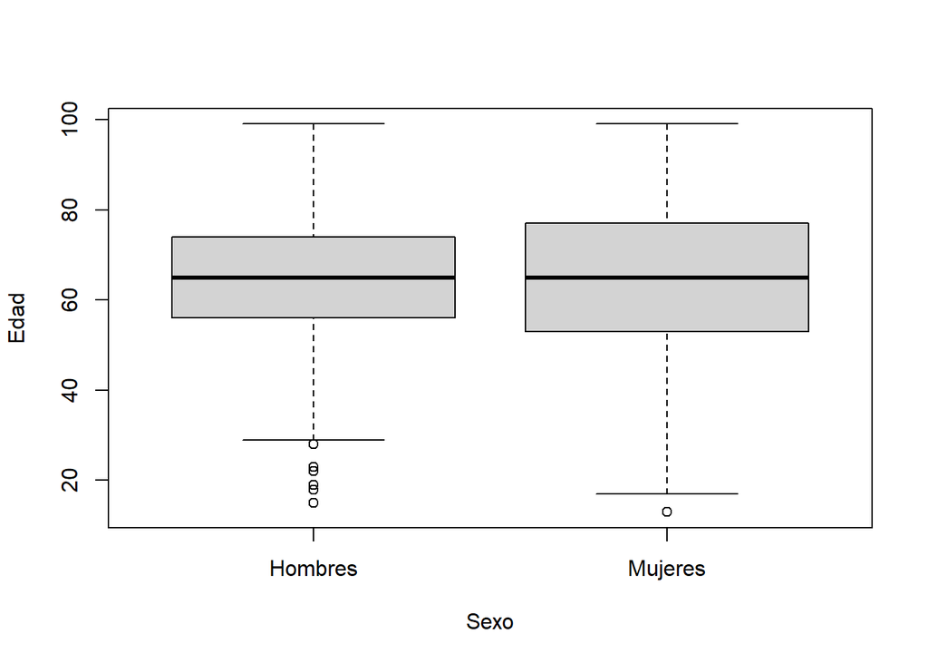

### Boxplot edad vs comuna

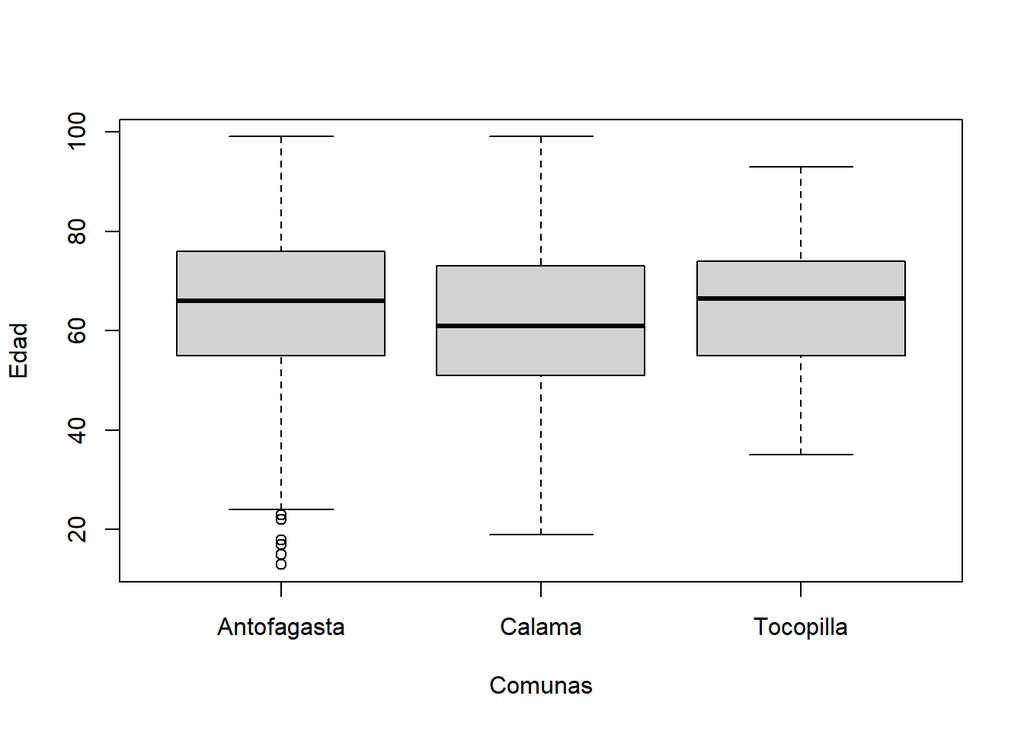

### Boxplot edad - morfologia

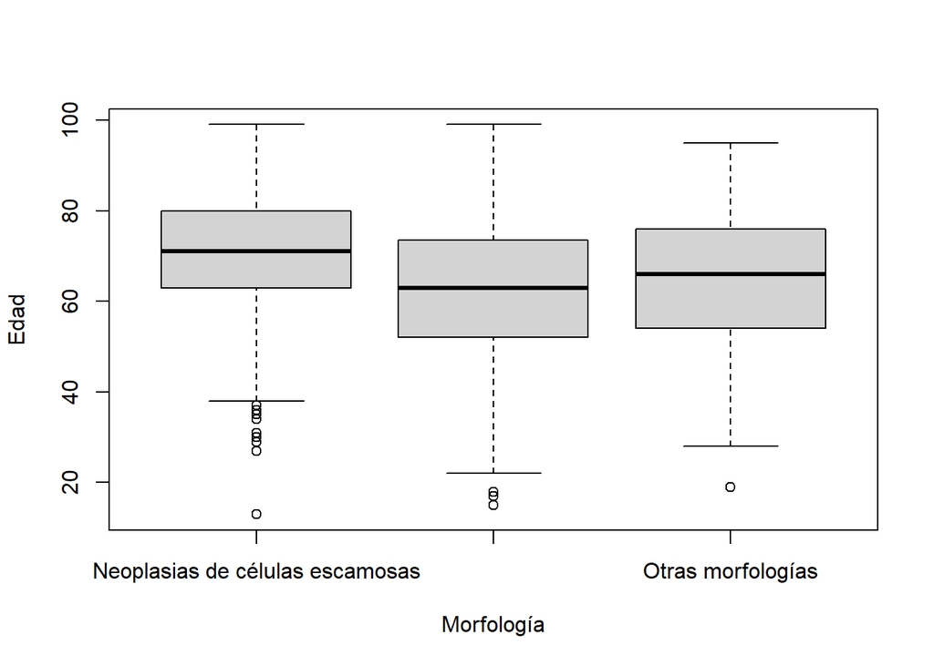

### Boxplot edad - extension

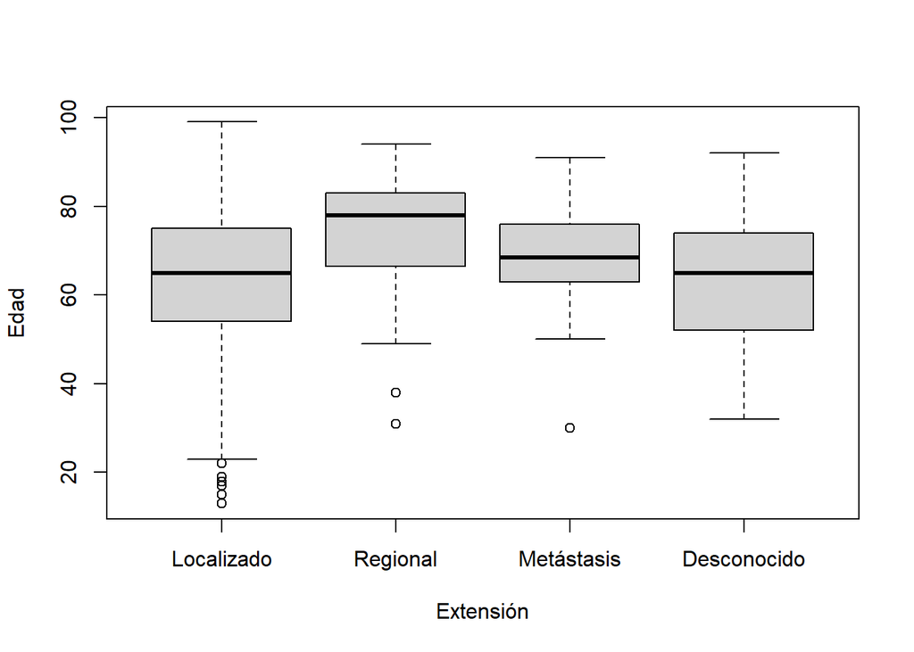

### Boxplot edad - base diagnóstica

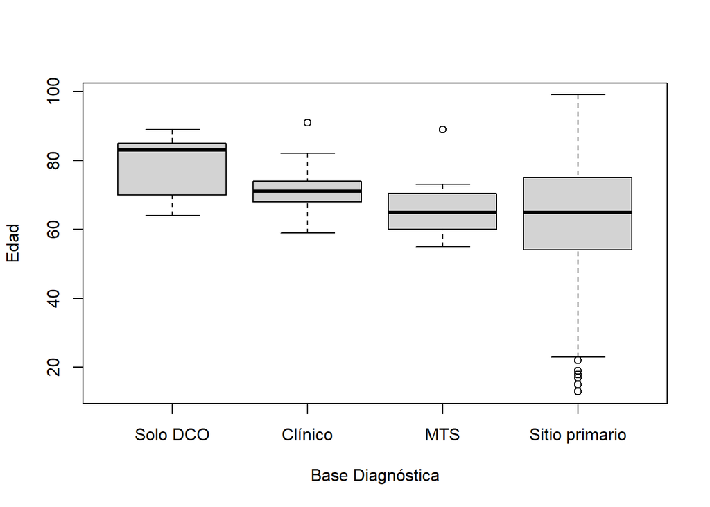

## Tasa de incidencia ajustada por año

| YEAR_DIAG | TASA_AJUSTADA |
| --- | --- |
| 2003 | 37.50642 |
| 2004 | 46.03468 |
| 2005 | 38.03996 |
| 2006 | 49.92155 |
| 2007 | 47.36482 |
| 2008 | 57.03016 |
| 2009 | 54.62820 |
| 2010 | 58.88847 |
| 2011 | 66.95047 |
| 2012 | 63.04982 |

[output cut: 3 more lines]

### Gráfico de la tasa de incidencia de cáncer de Piel (no melanoma), ajustada por edad en la región de Antofagasta.

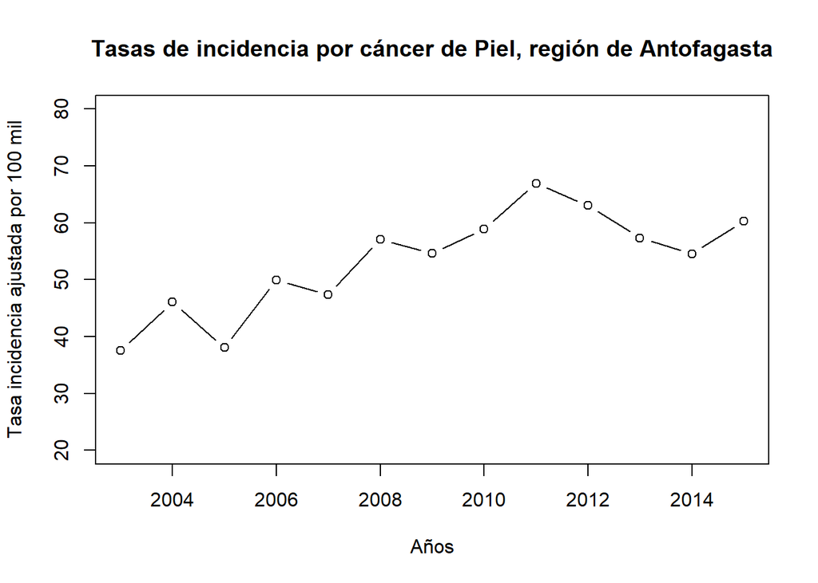

## Tasa de incidencia ajustada por edad y sexo, según año. Región de Antofagasta

| YEAR_DIAG | TASA_AJUSTADA | STD_ERROR |
| --- | --- | --- |
| 2003 | 20.15561 | 2.143241 |
| 2004 | 26.03693 | 2.393579 |
| 2005 | 17.64982 | 1.924346 |
| 2006 | 25.78176 | 2.317141 |
| 2007 | 24.99603 | 2.244428 |
| 2008 | 33.26657 | 2.567371 |
| 2009 | 29.12777 | 2.362630 |
| 2010 | 34.16552 | 2.547612 |
| 2011 | 34.56027 | 2.500861 |
| 2012 | 31.81445 | 2.386424 |

[output cut: 3 more lines]

| YEAR_DIAG | TASA_AJUSTADA | STD_ERROR |
| --- | --- | --- |
| 2003 | 17.35081 | 1.947027 |
| 2004 | 19.99775 | 2.021707 |
| 2005 | 20.39014 | 2.052653 |
| 2006 | 24.13979 | 2.217079 |
| 2007 | 22.36879 | 2.065239 |
| 2008 | 23.76359 | 2.048867 |
| 2009 | 25.50043 | 2.172480 |
| 2010 | 24.72295 | 2.093414 |
| 2011 | 32.39020 | 2.368083 |
| 2012 | 31.23537 | 2.273968 |

[output cut: 3 more lines]

### Gráfico de la tasa de incidencia de cáncer de Piel, ajustada por edad y sexo en la región de Antofagasta.

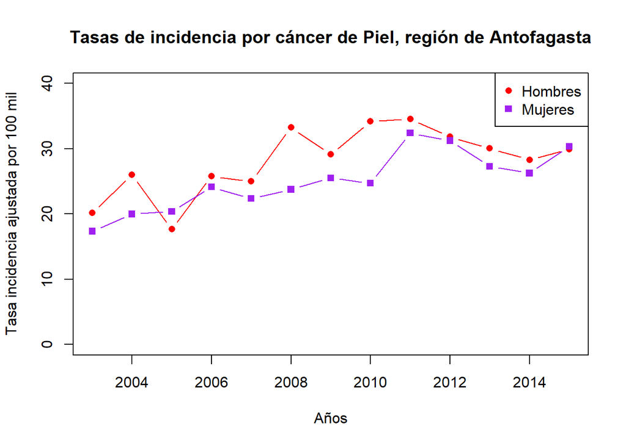

# Comuna de Antofagasta

### Número de casos por sexo, Comuna de Antofagasta

```
##
## Hombres Mujeres
##    1586    1508
```

### Proporción de casos por sexo, comuna de Antofagastas

```
##
## Hombres Mujeres
##   51.26   48.74
```

### Casos según morfología, comuna de Antofagasta

```
##
## Neoplasias de células escamosas   Neoplasias de células basales
##                             711                            2292
##               Otras morfologías
##                              91
```

### Proporción de casos según morfología, comuna de Antofagasta

```
##
## Neoplasias de células escamosas   Neoplasias de células basales
##                            23.0                            74.1
##               Otras morfologías
##                             2.9
```

### Casos según diferenciacion tumores, comuna de Antofagasta

```
##
##           Bien Diferenciado Moderadamente Diferenciados
##                         224                         378
##           Poco Diferenciado                  Anaplásico
##                          95                           1
##                 Desconocido
##                        2396
```

### Proporción de casos según diferenciación, Comuna de Antofagasta

```
##
##           Bien Diferenciado Moderadamente Diferenciados
##                        7.24                       12.22
##           Poco Diferenciado                  Anaplásico
##                        3.07                        0.03
##                 Desconocido
##                       77.44
```

### Casos según extensión tumoral, Comuna de Antofagasta

```
##
##  Localizado    Regional  Metástasis Desconocido
##        2927          31          31         105
```

### Proporción de casos según extensión tumoral, Comuna de Antofagasta

```
##
##  Localizado    Regional  Metástasis Desconocido
##       94.60        1.00        1.00        3.39
```

### Casos según base diagnóstico, Comuna de Antofagasta

```
##
##                     Solo DCO                      Clínica
##                            4                            7
##            Histología de MTS Histología de sitio primario
##                            6                         3077
```

### Proporción de casos según base diagnóstico, Comuna de Antofagasta

```
##
##                     Solo DCO                      Clínica
##                         0.13                         0.23
##            Histología de MTS Histología de sitio primario
##                         0.19                        99.45
```

### Edad, Comuna de Antofagasta

| Mínimo | Máximo | Rango | Qu_25 | Qu_50 | Qu_75 | Media | Mediana | Varianza | Desv_Estándar | CV |
| --- | --- | --- | --- | --- | --- | --- | --- | --- | --- | --- |
| 13 | 99 | 86 | 55 | 66 | 76 | 65.0779 | 66 | 194.7495 | 13.9553 | 21.4439 |

### Histrograma edad, Comuna de Antofagasta

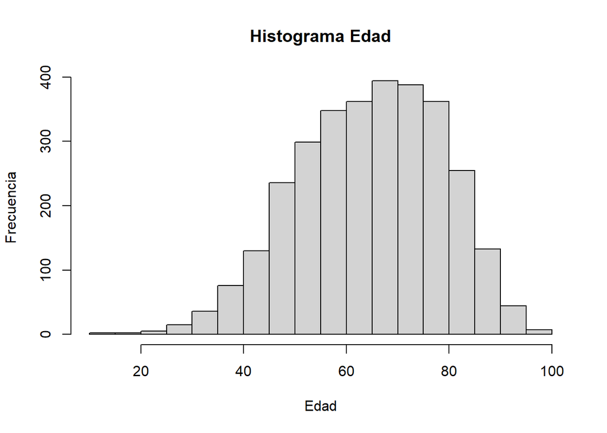

### Gráfico de densidad edad, Comuna de Antofagasta

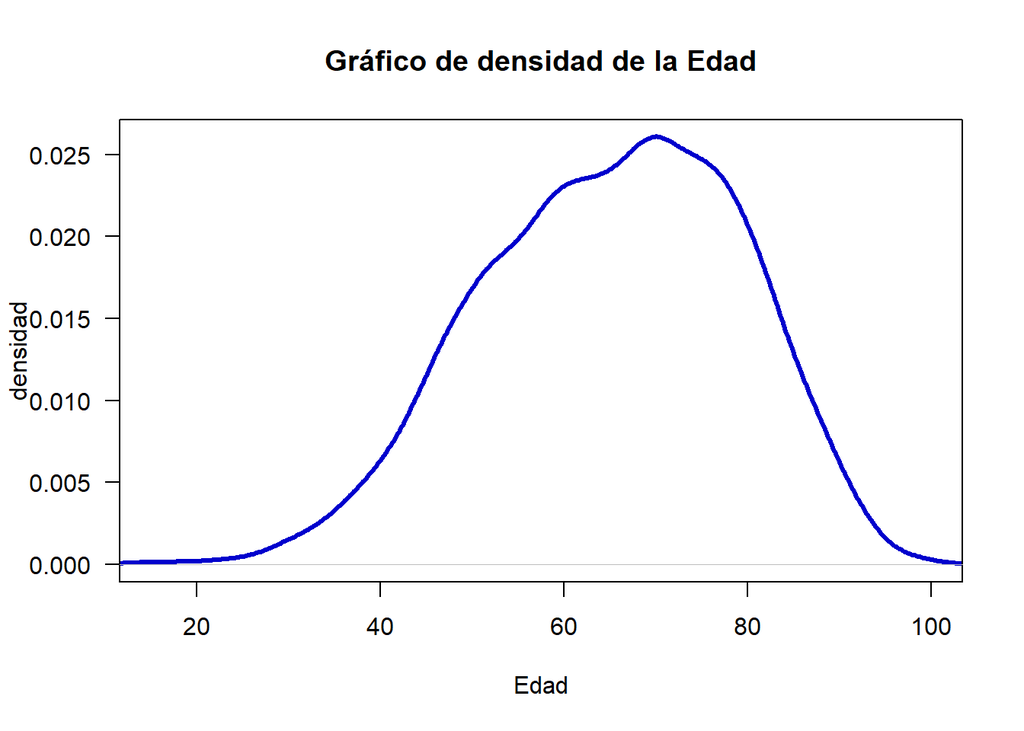

### Normal QQ, Comuna de Antofagasta

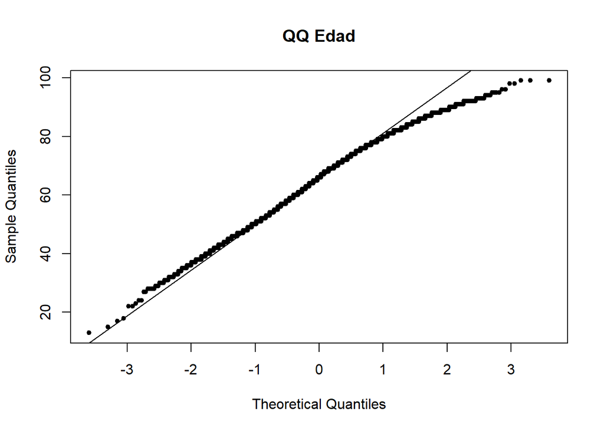

### Test de normalidad de Shapiro-Wilk, Comuna de Antofagasta

```
##
##  Shapiro-Wilk normality test
##
## data:  bd_1$EDAD
## W = 0.98955, p-value = 2.646e-14
```

## Estadística descriptiva Bivariada, comuna de Antofagasta

### Número de casos por sexo y morfología, comuna de Antofagasta

```
##
##                                   Hombres Mujeres  Sum
##   Neoplasias de células escamosas     430     281  711
##   Neoplasias de células basales      1104    1188 2292
##   Otras morfologías                    52      39   91
##   Sum                                1586    1508 3094
```

### Proporción de casos por sexo y morfología, comuna de Antofagasta

```
##
##                                   Hombres Mujeres    Sum
##   Neoplasias de células escamosas   60.48   39.52 100.00
##   Neoplasias de células basales     48.17   51.83 100.00
##   Otras morfologías                 57.14   42.86 100.00
```

### Número de casos por sexo y extensión tumoral, comuna de Antofagasta

```
##
##               Hombres Mujeres  Sum
##   Localizado     1488    1439 2927
##   Regional         15      16   31
##   Metástasis       21      10   31
##   Desconocido      62      43  105
##   Sum            1586    1508 3094
```

### Proporción de casos por sexo y extensión tumoral, Comuna de Antofagasta

```
##
##               Hombres Mujeres    Sum
##   Localizado    50.84   49.16 100.00
##   Regional      48.39   51.61 100.00
##   Metástasis    67.74   32.26 100.00
##   Desconocido   59.05   40.95 100.00
```

### Número de casos por sexo y base diagnóstica, comuna de Antofagasta

```
##
##                                Hombres Mujeres  Sum
##   Solo DCO                           2       2    4
##   Clínico                            4       3    7
##   Histología de Metástasis           4       2    6
##   Histología de sitio primario    1576    1501 3077
##   Sum                             1586    1508 3094
```

### Proporción de casos por sexo y base diagnóstica, comuna de Antofagasta

```
##
##                                Hombres Mujeres    Sum
##   Solo DCO                       50.00   50.00 100.00
##   Clínico                        57.14   42.86 100.00
##   Histología de Metástasis       66.67   33.33 100.00
##   Histología de sitio primario   51.22   48.78 100.00
```

### Número de casos por Morfología y base diagnóstica, comuna de Antofagasta

```
##
##                                   Solo DCO Clínico Histología de Metástasis
##   Neoplasias de células escamosas        0       0                        5
##   Neoplasias de células basales          0       0                        1
##   Otras morfologías                      4       7                        0
##   Sum                                    4       7                        6
##
##                                   Histología de sitio primario  Sum
##   Neoplasias de células escamosas                          706  711
##   Neoplasias de células basales                           2291 2292
##   Otras morfologías                                         80   91
##   Sum                                                     3077 3094
```

### Proporción de casos por Morfología y base diagnóstica, comuna de Antofagasta

```
##
##                                   Solo DCO Clínico Histología de Metástasis
##   Neoplasias de células escamosas     0.00    0.00                     0.70
##   Neoplasias de células basales       0.00    0.00                     0.04
##   Otras morfologías                   4.40    7.69                     0.00
##
##                                   Histología de sitio primario    Sum
##   Neoplasias de células escamosas                        99.30 100.00
##   Neoplasias de células basales                          99.96 100.00
##   Otras morfologías                                      87.91 100.00
```

### Número de casos por Morfología y Extensión, comuna de Antofagasta

```
##
##                                   Localizado Regional Metástasis Desconocido
##   Neoplasias de células escamosas        662       10         18          21
##   Neoplasias de células basales         2199       14          4          75
##   Otras morfologías                       66        7          9           9
##   Sum                                   2927       31         31         105
##
##                                    Sum
##   Neoplasias de células escamosas  711
##   Neoplasias de células basales   2292
##   Otras morfologías                 91
##   Sum                             3094
```

### Proporción de casos por Morfología y Extensión, comuna de Antofagasta

```
##
##                                   Localizado Regional Metástasis Desconocido
##   Neoplasias de células escamosas      93.11     1.41       2.53        2.95
##   Neoplasias de células basales        95.94     0.61       0.17        3.27
##   Otras morfologías                    72.53     7.69       9.89        9.89
##
##                                      Sum
##   Neoplasias de células escamosas 100.00
##   Neoplasias de células basales   100.00
##   Otras morfologías               100.00
```

### Número de casos por Extensión y Base diagnóstica, comuna de Antofagasta

```
##
##               Solo DCO Clínico Histología de Metástasis
##   Localizado         0       2                        2
##   Regional           0       2                        1
##   Metástasis         0       3                        3
##   Desconocido        4       0                        0
##   Sum                4       7                        6
##
##               Histología de sitio primario  Sum
##   Localizado                          2923 2927
##   Regional                              28   31
##   Metástasis                            25   31
##   Desconocido                          101  105
##   Sum                                 3077 3094
```

### Proporción de casos por Extensión y Base diagnóstica, filas, comuna de Antofagastas

```
##
##               Solo DCO Clínico Histología de Metástasis
##   Localizado      0.00    0.07                     0.07
##   Regional        0.00    6.45                     3.23
##   Metástasis      0.00    9.68                     9.68
##   Desconocido     3.81    0.00                     0.00
##
##               Histología de sitio primario    Sum
##   Localizado                         99.86 100.00
##   Regional                           90.32 100.00
##   Metástasis                         80.65 100.00
##   Desconocido                        96.19 100.00
```

### Proporción de casos por Extensión y Base diagnóstica, columnas, Comuna de Antofagasta

```
##
##               Solo DCO Clínico Histología de Metástasis
##   Localizado      0.00   28.57                    33.33
##   Regional        0.00   28.57                    16.67
##   Metástasis      0.00   42.86                    50.00
##   Desconocido   100.00    0.00                     0.00
##   Sum           100.00  100.00                   100.00
##
##               Histología de sitio primario
##   Localizado                         95.00
##   Regional                            0.91
##   Metástasis                          0.81
##   Desconocido                         3.28
##   Sum                               100.00
```

### Edad - Sexo

#### Boxplot edad vs sexo, Comuna de Antofagasta

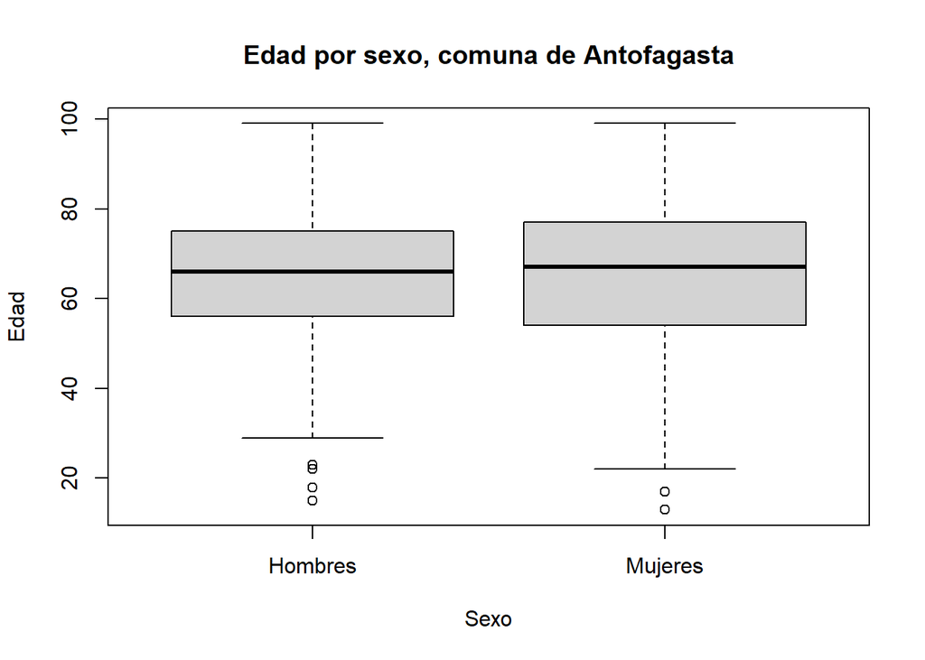

### Boxplot edad - morfologia, Comuna de Antofagasta

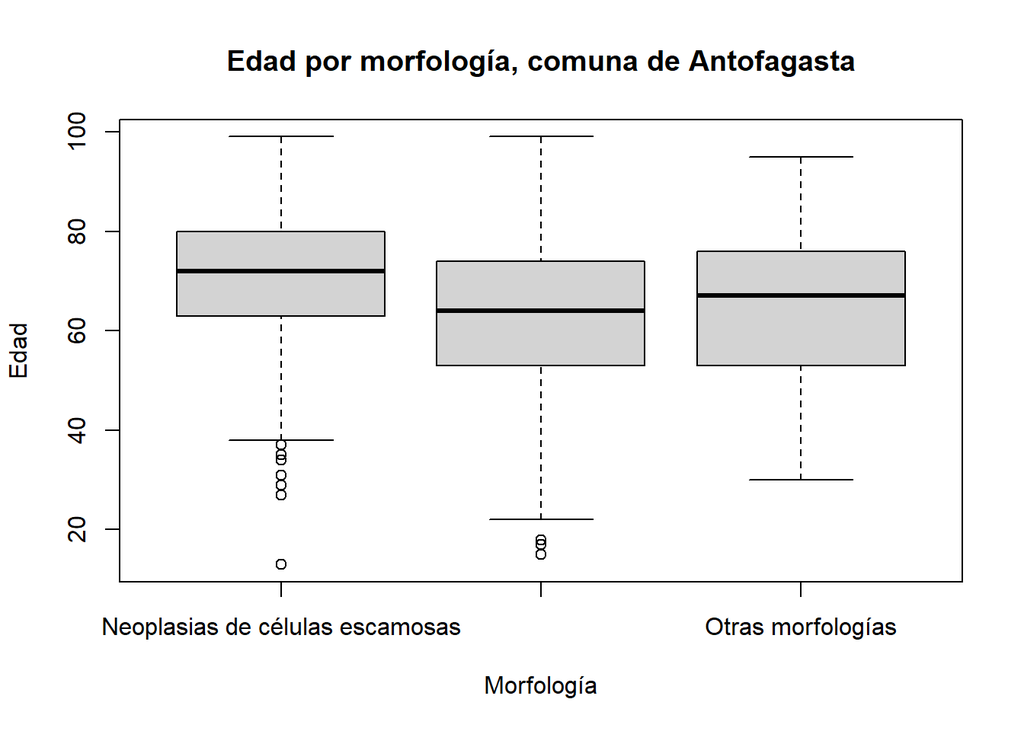

### Boxplot edad - extension, Comuna de Antofagasta

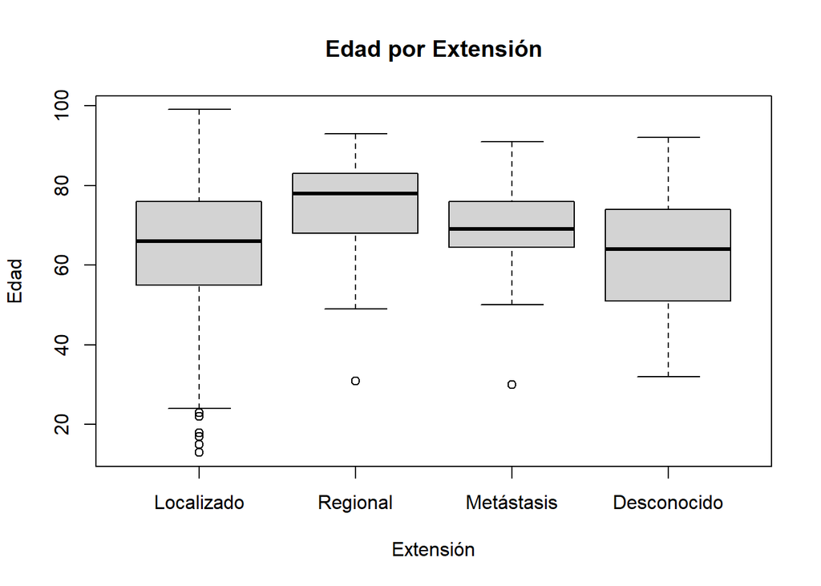

### Boxplot edad - base diagnóstica, Comuna de Antofagasta

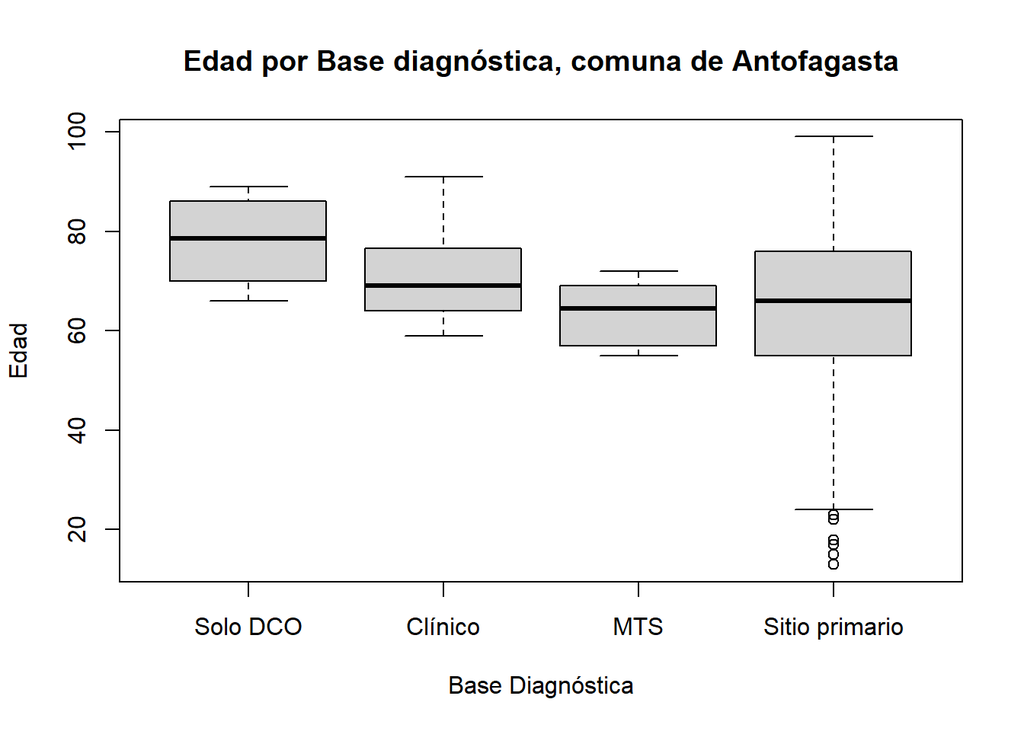

## Tasa de incidencia ajustada por año, Comuna de Antofagasta

| YEAR_DIAG | TASA_AJUSTADA |
| --- | --- |
| 2003 | 49.43052 |
| 2004 | 57.93156 |
| 2005 | 47.30402 |
| 2006 | 59.14230 |
| 2007 | 56.65451 |
| 2008 | 69.39023 |
| 2009 | 71.94688 |
| 2010 | 72.33151 |
| 2011 | 79.63372 |
| 2012 | 79.83613 |

[output cut: 3 more lines]

### Gráfico de la tasa de incidencia de cáncer de Piel (no melanoma), ajustada por edad en Comuna de Antofagasta

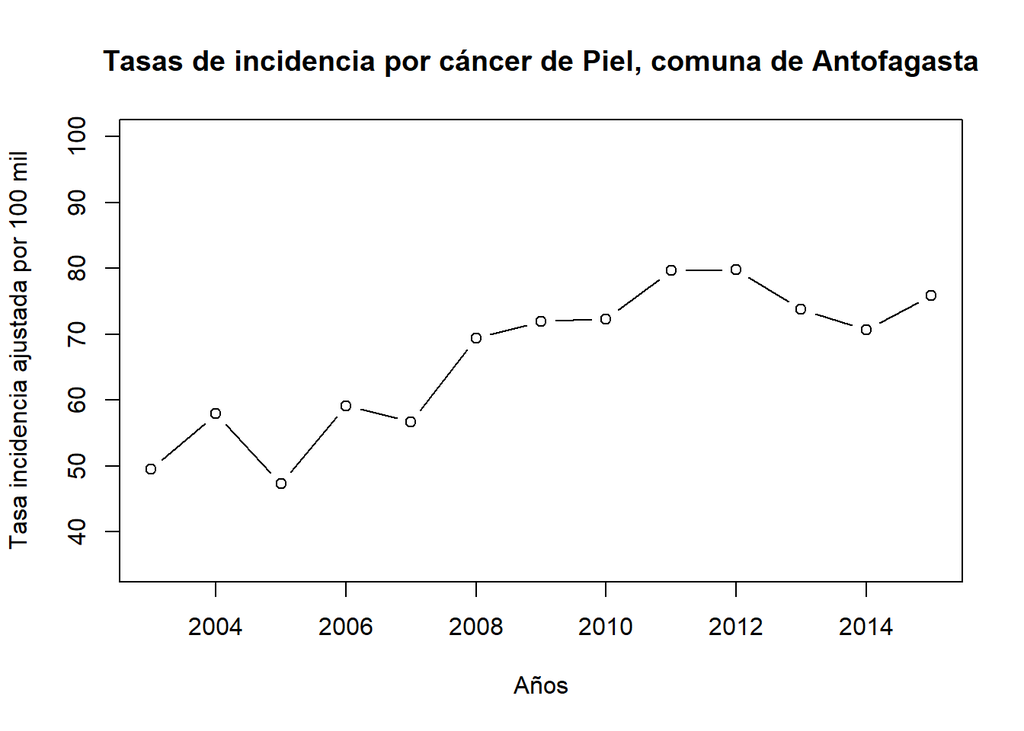

## Tasa de incidencia ajustada por edad y sexo, según año. Comuna de Antofagasta

| YEAR_DIAG | TASA_AJUSTADA | STD_ERROR |
| --- | --- | --- |
| 2003 | 27.10635 | 3.124144 |
| 2004 | 34.35830 | 3.483740 |
| 2005 | 21.86088 | 2.712401 |
| 2006 | 29.82460 | 3.150750 |
| 2007 | 29.72056 | 3.105340 |
| 2008 | 38.37816 | 3.458733 |
| 2009 | 38.01681 | 3.418376 |
| 2010 | 43.28343 | 3.650637 |
| 2011 | 41.11324 | 3.467832 |
| 2012 | 39.76859 | 3.413657 |

[output cut: 3 more lines]

| YEAR_DIAG | TASA_AJUSTADA | STD_ERROR |
| --- | --- | --- |
| 2003 | 22.32417 | 2.784742 |
| 2004 | 23.57326 | 2.802515 |
| 2005 | 25.44314 | 2.884856 |
| 2006 | 29.31770 | 3.111408 |
| 2007 | 26.93395 | 2.885253 |
| 2008 | 31.01206 | 2.984940 |
| 2009 | 33.93007 | 3.190021 |
| 2010 | 29.04808 | 2.860660 |
| 2011 | 38.52048 | 3.274690 |
| 2012 | 40.06754 | 3.289432 |

[output cut: 3 more lines]

### Gráfico de la tasa de incidencia de cáncer de Piel, ajustada por edad y sexo en la comuna de Antofagasta.

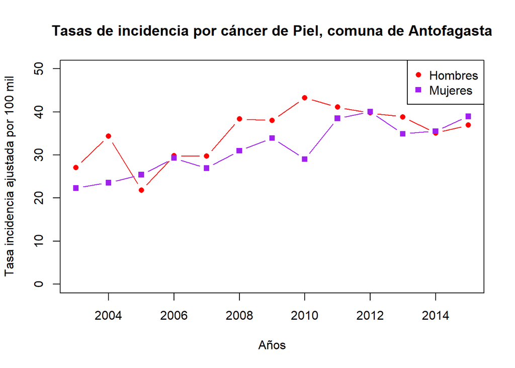

# Comuna de Calama

### Número de casos por sexo, Comuna de Calama

```
##
## Hombres Mujeres
##     271     227
```

### Proporción de casos por sexo, comuna de Calama

```
##
## Hombres Mujeres
##   54.42   45.58
```

### Casos según morfología, comuna de Calama

```
##
## Neoplasias de células escamosas   Neoplasias de células basales
##                              92                             387
##               Otras morfologías
##                              19
```

### Proporción de casos según morfología, comuna de Calama

```
##
## Neoplasias de células escamosas   Neoplasias de células basales
##                            18.5                            77.7
##               Otras morfologías
##                             3.8
```

### Casos según diferenciacion tumores, comuna de Calama

```
##
##           Bien Diferenciado Moderadamente Diferenciados
##                          39                          31
##           Poco Diferenciado                  Anaplásico
##                          12                           1
##                 Desconocido
##                         415
```

### Proporción de casos según diferenciación, Comuna de Calama

```
##
##           Bien Diferenciado Moderadamente Diferenciados
##                        7.83                        6.22
##           Poco Diferenciado                  Anaplásico
##                        2.41                        0.20
##                 Desconocido
##                       83.33
```

### Casos según extensión tumoral, Comuna de Calama

```
##
##  Localizado    Regional  Metástasis Desconocido
##         467           6           6          19
```

### Proporción de casos según extensión tumoral, Comuna de Calama

```
##
##  Localizado    Regional  Metástasis Desconocido
##       93.78        1.20        1.20        3.82
```

### Casos según base diagnóstico, Comuna de Calama

```
##
##                     Solo DCO                      Clínica
##                            2                            1
##            Histología de MTS Histología de sitio primario
##                            5                          490
```

### Proporción de casos según base diagnóstico, Comuna de Calama

```
##
##                     Solo DCO                      Clínica
##                         0.40                         0.20
##            Histología de MTS Histología de sitio primario
##                         1.00                        98.39
```

### Edad, Comuna de Calama

| Mínimo | Máximo | Rango | Qu_25 | Qu_50 | Qu_75 | Media | Mediana | Varianza | Desv_Estándar | CV |
| --- | --- | --- | --- | --- | --- | --- | --- | --- | --- | --- |
| 19 | 99 | 80 | 51 | 61 | 73 | 61.8273 | 61 | 214.0184 | 14.6294 | 23.6617 |

### Histrograma edad, Comuna de Calama

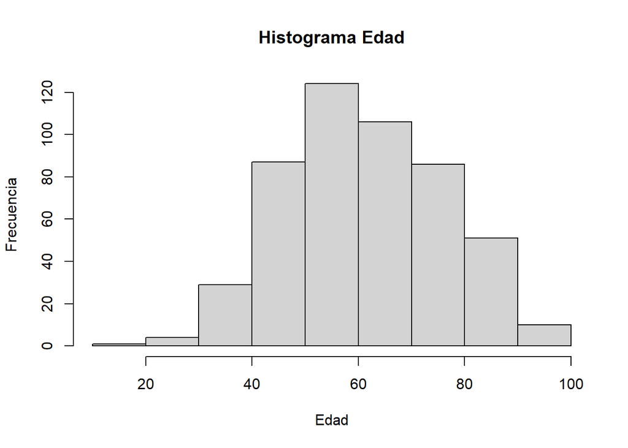

### Gráfico de densidad edad, Comuna de Calama

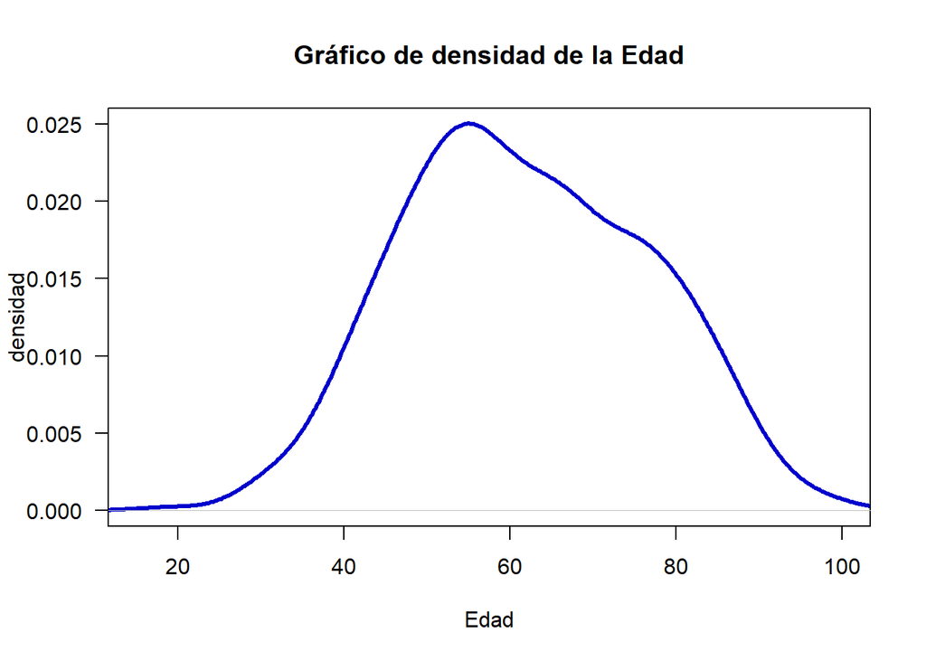

### Normal QQ, Comuna de Calama

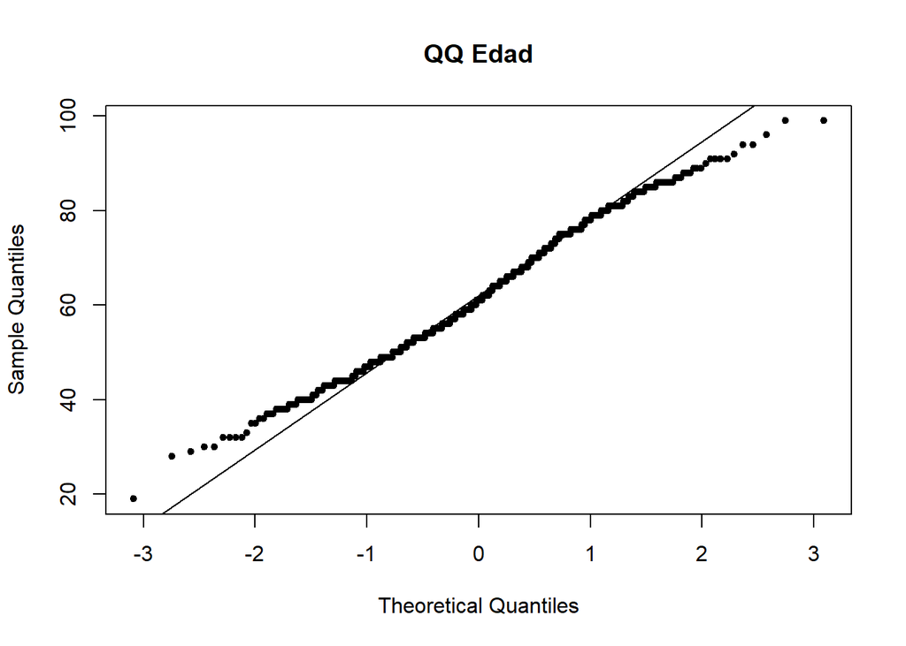

### Test de normalidad de Shapiro-Wilk, Comuna de Calama

```
##
##  Shapiro-Wilk normality test
##
## data:  bd_2$EDAD
## W = 0.99076, p-value = 0.003293
```

## Estadística descriptiva Bivariada, comuna de Calama

### Número de casos por sexo y morfología, comuna de Calama

```
##
##                                   Hombres Mujeres Sum
##   Neoplasias de células escamosas      51      41  92
##   Neoplasias de células basales       211     176 387
##   Otras morfologías                     9      10  19
##   Sum                                 271     227 498
```

### Proporción de casos por sexo y morfología, comuna de Calama

```
##
##                                   Hombres Mujeres    Sum
##   Neoplasias de células escamosas   55.43   44.57 100.00
##   Neoplasias de células basales     54.52   45.48 100.00
##   Otras morfologías                 47.37   52.63 100.00
```

### Número de casos por sexo y extensión tumoral, comuna de Calama

```
##
##               Hombres Mujeres Sum
##   Localizado      256     211 467
##   Regional          3       3   6
##   Metástasis        1       5   6
##   Desconocido      11       8  19
##   Sum             271     227 498
```

### Proporción de casos por sexo y extensión tumoral, Comuna de Calama

```
##
##               Hombres Mujeres    Sum
##   Localizado    54.82   45.18 100.00
##   Regional      50.00   50.00 100.00
##   Metástasis    16.67   83.33 100.00
##   Desconocido   57.89   42.11 100.00
```

### Número de casos por sexo y base diagnóstica, comuna de Calama

```
##
##                                Hombres Mujeres Sum
##   Solo DCO                           1       1   2
##   Clínico                            0       1   1
##   Histología de Metástasis           2       3   5
##   Histología de sitio primario     268     222 490
##   Sum                              271     227 498
```

### Proporción de casos por sexo y base diagnóstica, comuna de Calama

```
##
##                                Hombres Mujeres    Sum
##   Solo DCO                       50.00   50.00 100.00
##   Clínico                         0.00  100.00 100.00
##   Histología de Metástasis       40.00   60.00 100.00
##   Histología de sitio primario   54.69   45.31 100.00
```

### Número de casos por Morfología y base diagnóstica, comuna de Calama

```
##
##                                   Solo DCO Clínico Histología de Metástasis
##   Neoplasias de células escamosas        0       0                        2
##   Neoplasias de células basales          0       0                        2
##   Otras morfologías                      2       1                        1
##   Sum                                    2       1                        5
##
##                                   Histología de sitio primario Sum
##   Neoplasias de células escamosas                           90  92
##   Neoplasias de células basales                            385 387
##   Otras morfologías                                         15  19
##   Sum                                                      490 498
```

### Proporción de casos por Morfología y base diagnóstica, comuna de Calama

```
##
##                                   Solo DCO Clínico Histología de Metástasis
##   Neoplasias de células escamosas     0.00    0.00                     2.17
##   Neoplasias de células basales       0.00    0.00                     0.52
##   Otras morfologías                  10.53    5.26                     5.26
##
##                                   Histología de sitio primario    Sum
##   Neoplasias de células escamosas                        97.83 100.00
##   Neoplasias de células basales                          99.48 100.00
##   Otras morfologías                                      78.95 100.00
```

### Número de casos por Morfología y Extensión, comuna de Calama

```
##
##                                   Localizado Regional Metástasis Desconocido
##   Neoplasias de células escamosas         86        2          2           2
##   Neoplasias de células basales          370        4          1          12
##   Otras morfologías                       11        0          3           5
##   Sum                                    467        6          6          19
##
##                                   Sum
##   Neoplasias de células escamosas  92
##   Neoplasias de células basales   387
##   Otras morfologías                19
##   Sum                             498
```

### Proporción de casos por Morfología y Extensión, comuna de Calama

```
##
##                                   Localizado Regional Metástasis Desconocido
##   Neoplasias de células escamosas      93.48     2.17       2.17        2.17
##   Neoplasias de células basales        95.61     1.03       0.26        3.10
##   Otras morfologías                    57.89     0.00      15.79       26.32
##
##                                      Sum
##   Neoplasias de células escamosas 100.00
##   Neoplasias de células basales   100.00
##   Otras morfologías               100.00
```

### Número de casos por Extensión y Base diagnóstica, comuna de Calama

```
##
##               Solo DCO Clínico Histología de Metástasis
##   Localizado         0       0                        2
##   Regional           0       0                        0
##   Metástasis         1       0                        3
##   Desconocido        1       1                        0
##   Sum                2       1                        5
##
##               Histología de sitio primario Sum
##   Localizado                           465 467
##   Regional                               6   6
##   Metástasis                             2   6
##   Desconocido                           17  19
##   Sum                                  490 498
```

### Proporción de casos por Extensión y Base diagnóstica, filas, comuna de Calama

```
##
##               Solo DCO Clínico Histología de Metástasis
##   Localizado      0.00    0.00                     0.43
##   Regional        0.00    0.00                     0.00
##   Metástasis     16.67    0.00                    50.00
##   Desconocido     5.26    5.26                     0.00
##
##               Histología de sitio primario    Sum
##   Localizado                         99.57 100.00
##   Regional                          100.00 100.00
##   Metástasis                         33.33 100.00
##   Desconocido                        89.47 100.00
```

### Proporción de casos por Extensión y Base diagnóstica, columnas, Comuna de Calama

```
##
##               Solo DCO Clínico Histología de Metástasis
##   Localizado      0.00    0.00                    40.00
##   Regional        0.00    0.00                     0.00
##   Metástasis     50.00    0.00                    60.00
##   Desconocido    50.00  100.00                     0.00
##   Sum           100.00  100.00                   100.00
##
##               Histología de sitio primario
##   Localizado                         94.90
##   Regional                            1.22
##   Metástasis                          0.41
##   Desconocido                         3.47
##   Sum                               100.00
```

### Edad - Sexo

#### Boxplot edad vs sexo, Comuna de Calama

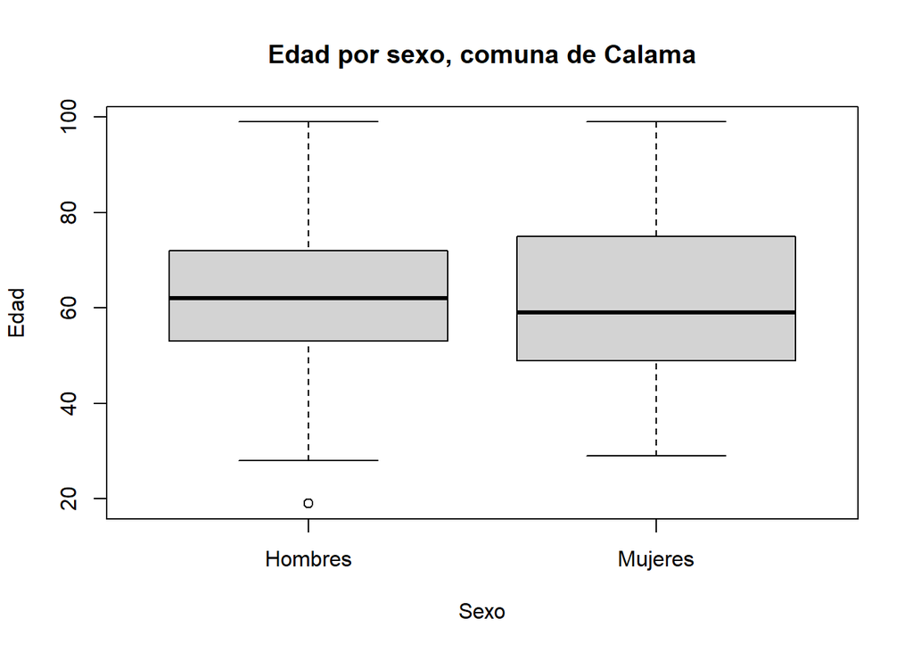

### Boxplot edad - morfologia, Comuna de Calama

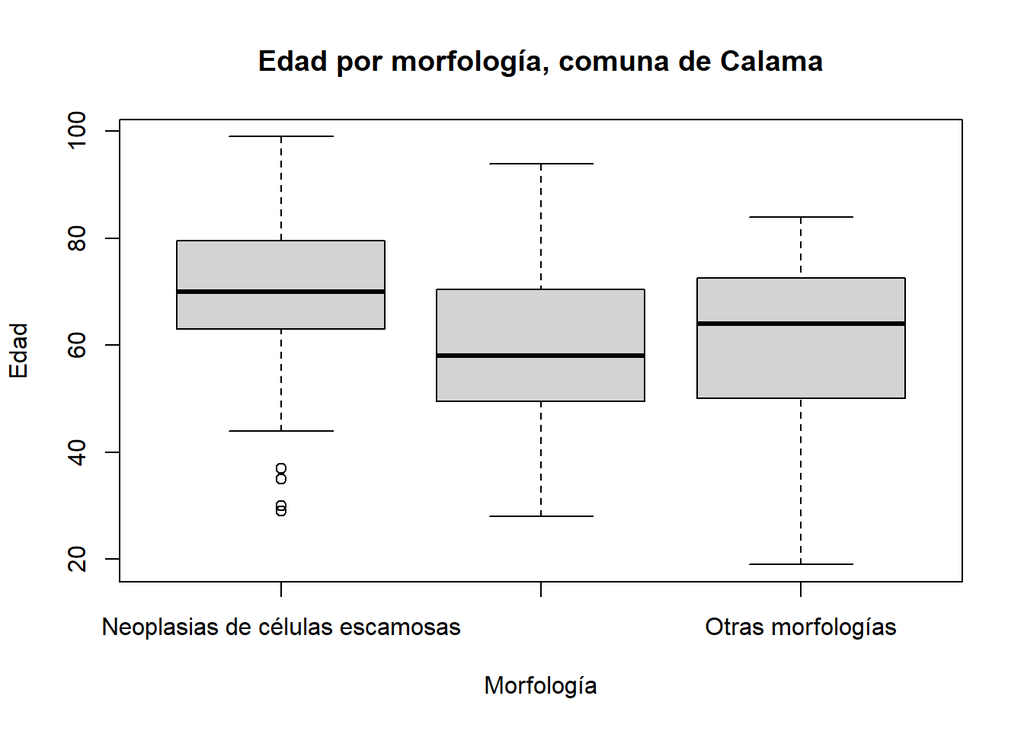

### Boxplot edad - extension, Comuna de Calama

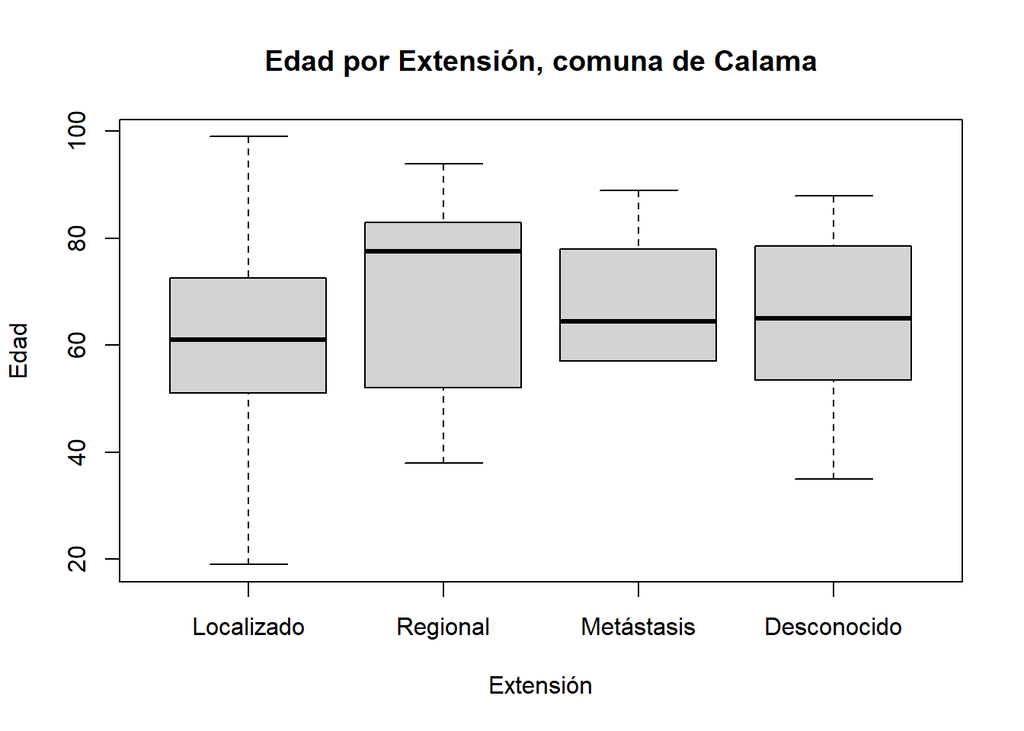

### Boxplot edad - base diagnóstica, Comuna de Calama

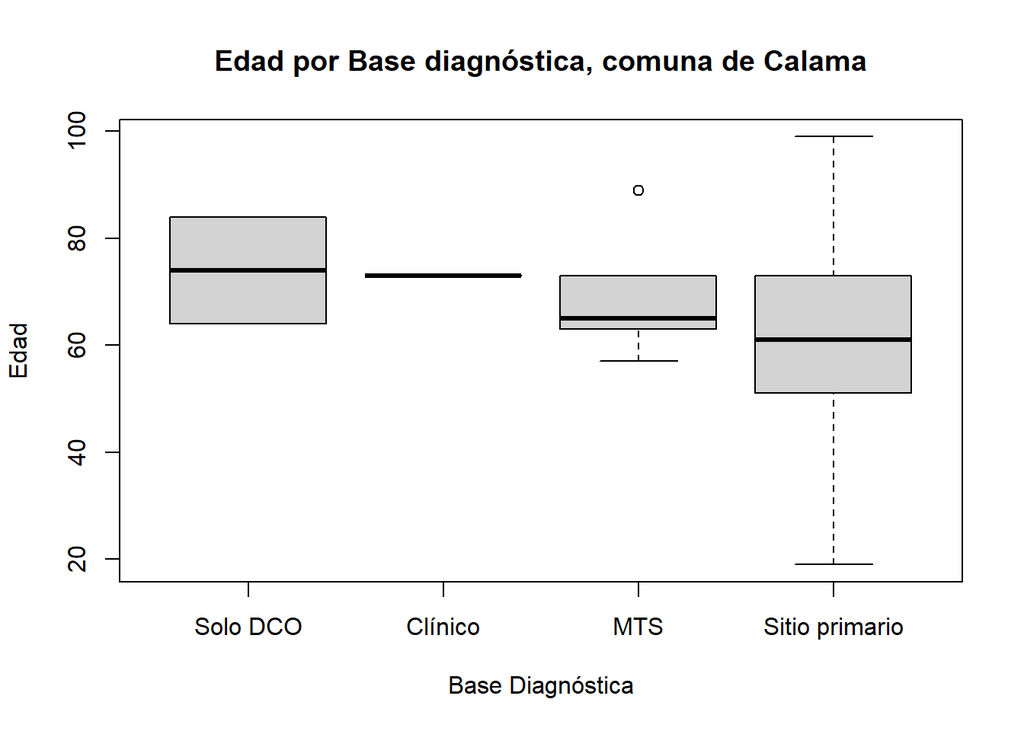

## Tasa de incidencia ajustada por año, Comuna de Calama

| YEAR_DIAG | TASA_AJUSTADA |
| --- | --- |
| 2003 | 15.79046 |
| 2004 | 22.89051 |
| 2005 | 24.20970 |
| 2006 | 23.70614 |
| 2007 | 23.86700 |
| 2008 | 30.25192 |
| 2009 | 27.69541 |
| 2010 | 28.47099 |
| 2011 | 39.10343 |
| 2012 | 35.96044 |

[output cut: 3 more lines]

### Gráfico de la tasa de incidencia de cáncer de piel (No melanoma), ajustada por edad en Comuna de Calama

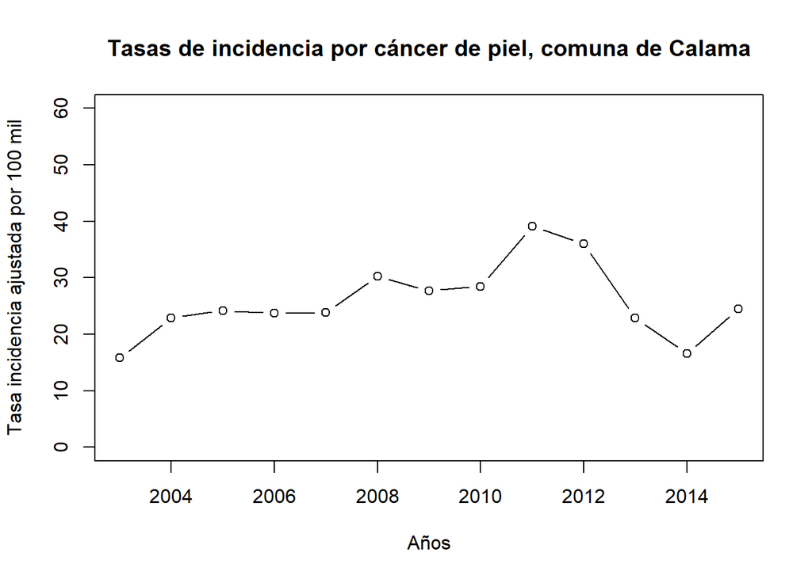

## Tasa de incidencia ajustada por edad y sexo, según año. Comuna de Calama

| YEAR_DIAG | TASA_AJUSTADA | STD_ERROR |
| --- | --- | --- |
| 2003 | 9.058421 | 2.944650 |
| 2004 | 11.841682 | 3.261994 |
| 2005 | 12.280884 | 3.193338 |
| 2006 | 14.816407 | 3.511364 |
| 2007 | 12.614323 | 3.068781 |
| 2008 | 21.051757 | 4.133489 |
| 2009 | 18.024659 | 3.782196 |
| 2010 | 12.439543 | 3.023478 |
| 2011 | 22.069959 | 3.968917 |
| 2012 | 19.603849 | 3.551372 |

[output cut: 3 more lines]

| YEAR_DIAG | TASA_AJUSTADA | STD_ERROR |
| --- | --- | --- |
| 2003 | 6.732043 | 2.494599 |
| 2004 | 11.048823 | 2.811681 |
| 2005 | 11.928816 | 3.210912 |
| 2006 | 8.889735 | 2.555202 |
| 2007 | 11.252674 | 2.815905 |
| 2008 | 9.200160 | 2.417731 |
| 2009 | 9.670750 | 2.584648 |
| 2010 | 16.031450 | 3.436511 |
| 2011 | 17.033467 | 3.445475 |
| 2012 | 16.356591 | 3.225480 |

[output cut: 3 more lines]

### Gráfico de la tasa de incidencia de cáncer de Piel, ajustada por edad y sexo en la comuna de Calama

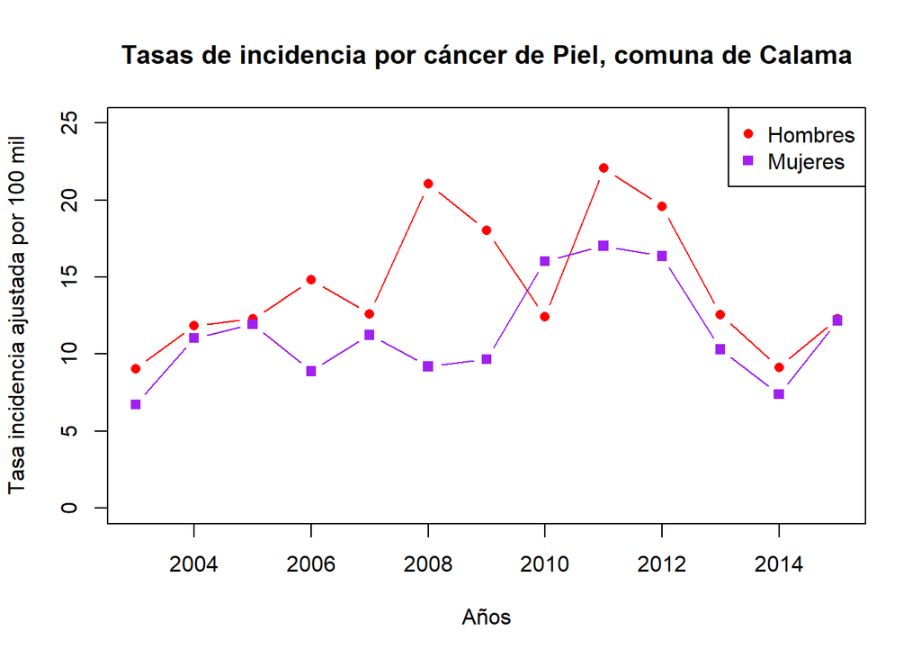

# Comuna de Tocopilla

### Número de casos por sexo, Comuna de Tocopilla

```
##
## Hombres Mujeres
##      96     114
```

### Proporción de casos por sexo, comuna de Tocopilla

```
##
## Hombres Mujeres
##   45.71   54.29
```

### Casos según morfología, comuna de Tocopilla

```
##
## Neoplasias de células escamosas   Neoplasias de células basales
##                              54                             148
##               Otras morfologías
##                               8
```

### Proporción de casos según morfología, comuna de Tocopilla

```
##
## Neoplasias de células escamosas   Neoplasias de células basales
##                            25.7                            70.5
##               Otras morfologías
##                             3.8
```

### Casos según diferenciacion tumores, comuna de Tocopilla

```
##
##           Bien Diferenciado Moderadamente Diferenciados
##                          22                          25
##           Poco Diferenciado                  Anaplásico
##                           6                           0
##                 Desconocido
##                         157
```

### Proporción de casos según diferenciación, Comuna de Tocopilla

```
##
##           Bien Diferenciado Moderadamente Diferenciados
##                       10.48                       11.90
##           Poco Diferenciado                  Anaplásico
##                        2.86                        0.00
##                 Desconocido
##                       74.76
```

### Casos según extensión tumoral, Comuna de Tocopilla

```
##
##  Localizado    Regional  Metástasis Desconocido
##         202           1           3           4
```

### Proporción de casos según extensión tumoral, Comuna de Tocopilla

```
##
##  Localizado    Regional  Metástasis Desconocido
##       96.19        0.48        1.43        1.90
```

### Casos según base diagnóstico, Comuna de Tocopilla

```
##
##                     Solo DCO                      Clínica
##                            1                            1
##            Histología de MTS Histología de sitio primario
##                            0                          208
```

### Proporción de casos según base diagnóstico, Comuna de Tocopilla

```
##
##                     Solo DCO                      Clínica
##                         0.48                         0.48
##            Histología de MTS Histología de sitio primario
##                         0.00                        99.05
```

### Edad, Comuna de Tocopilla

| Mínimo | Máximo | Rango | Qu_25 | Qu_50 | Qu_75 | Media | Mediana | Varianza | Desv_Estándar | CV |
| --- | --- | --- | --- | --- | --- | --- | --- | --- | --- | --- |
| 35 | 93 | 58 | 55.25 | 66.5 | 74 | 65.1095 | 66.5 | 154.7009 | 12.4379 | 19.103 |

### Histrograma edad, Comuna de Tocopilla

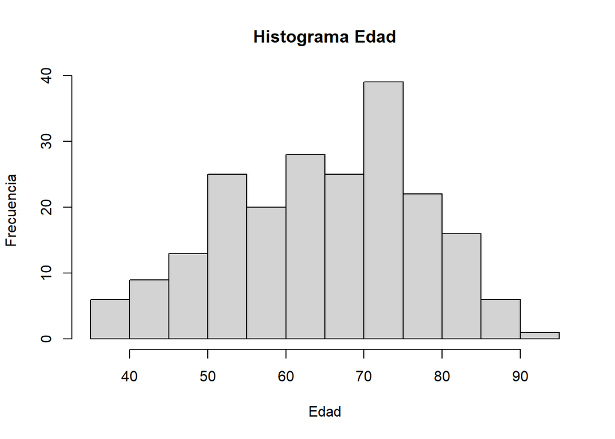

### Gráfico de densidad edad, Comuna de Tocopilla

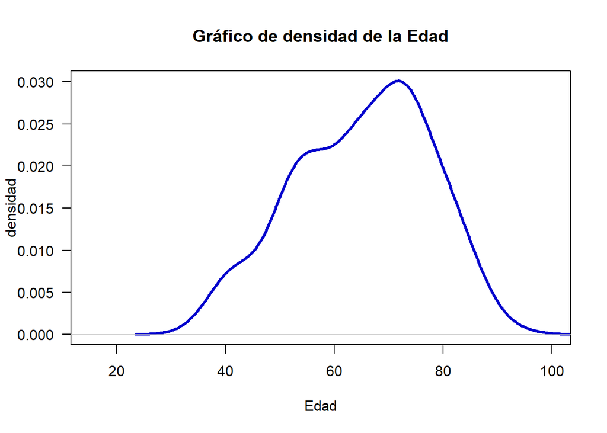

### Normal QQ, Comuna de Tocopilla

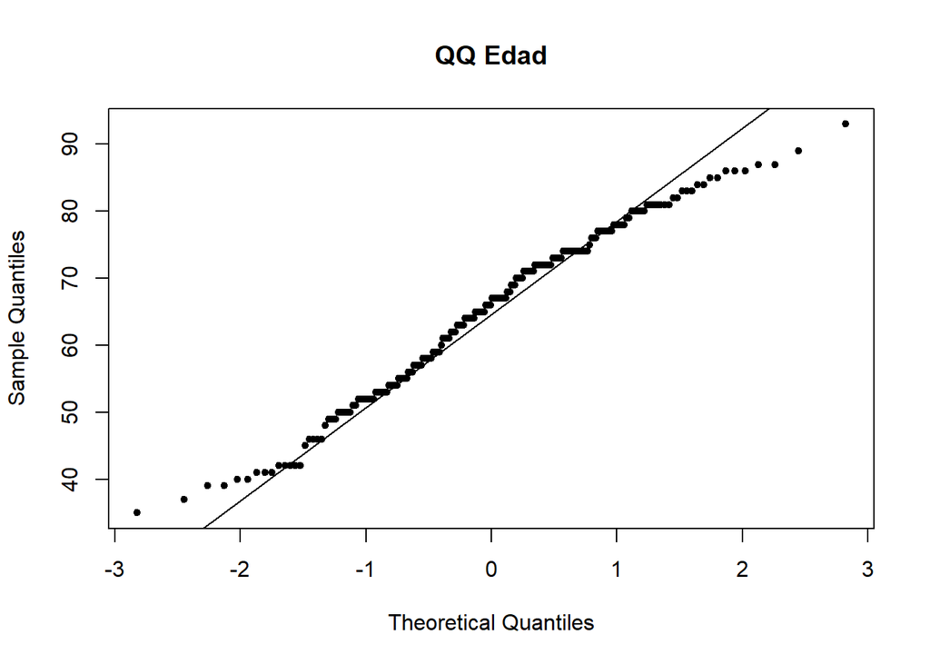

### Test de normalidad de Shapiro-Wilk, Comuna de Tocopilla

```
##
##  Shapiro-Wilk normality test
##
## data:  bd_3$EDAD
## W = 0.98083, p-value = 0.005849
```

## Estadística descriptiva Bivariada, comuna de Tocopilla

### Número de casos por sexo y morfología, comuna de Tocopilla

```
##
##                                   Hombres Mujeres Sum
##   Neoplasias de células escamosas      33      21  54
##   Neoplasias de células basales        59      89 148
##   Otras morfologías                     4       4   8
##   Sum                                  96     114 210
```

### Proporción de casos por sexo y morfología, comuna de Tocopilla

```
##
##                                   Hombres Mujeres    Sum
##   Neoplasias de células escamosas   61.11   38.89 100.00
##   Neoplasias de células basales     39.86   60.14 100.00
##   Otras morfologías                 50.00   50.00 100.00
```

### Número de casos por sexo y extensión tumoral, comuna de Tocopilla

```
##
##               Hombres Mujeres Sum
##   Localizado       92     110 202
##   Regional          0       1   1
##   Metástasis        3       0   3
##   Desconocido       1       3   4
##   Sum              96     114 210
```

### Proporción de casos por sexo y extensión tumoral, Comuna de Tocopilla

```
##
##               Hombres Mujeres    Sum
##   Localizado    45.54   54.46 100.00
##   Regional       0.00  100.00 100.00
##   Metástasis   100.00    0.00 100.00
##   Desconocido   25.00   75.00 100.00
```

### Número de casos por sexo y base diagnóstica, comuna de Tocopilla

```
##
##                                Hombres Mujeres Sum
##   Solo DCO                           0       1   1
##   Clínico                            1       0   1
##   Histología de Metástasis           0       0   0
##   Histología de sitio primario      95     113 208
##   Sum                               96     114 210
```

### Proporción de casos por sexo y base diagnóstica, comuna de Tocopilla

```
##
##                                Hombres Mujeres    Sum
##   Solo DCO                        0.00  100.00 100.00
##   Clínico                       100.00    0.00 100.00
##   Histología de Metástasis
##   Histología de sitio primario   45.67   54.33 100.00
```

### Número de casos por Morfología y base diagnóstica, comuna de Tocopilla

```
##
##                                   Solo DCO Clínico Histología de Metástasis
##   Neoplasias de células escamosas        0       0                        0
##   Neoplasias de células basales          0       0                        0
##   Otras morfologías                      1       1                        0
##   Sum                                    1       1                        0
##
##                                   Histología de sitio primario Sum
##   Neoplasias de células escamosas                           54  54
##   Neoplasias de células basales                            148 148
##   Otras morfologías                                          6   8
##   Sum                                                      208 210
```

### Proporción de casos por Morfología y base diagnóstica, comuna de Tocopilla

```
##
##                                   Solo DCO Clínico Histología de Metástasis
##   Neoplasias de células escamosas      0.0     0.0                      0.0
##   Neoplasias de células basales        0.0     0.0                      0.0
##   Otras morfologías                   12.5    12.5                      0.0
##
##                                   Histología de sitio primario   Sum
##   Neoplasias de células escamosas                        100.0 100.0
##   Neoplasias de células basales                          100.0 100.0
##   Otras morfologías                                       75.0 100.0
```

### Número de casos por Morfología y Extensión, comuna de Tocopilla

```
##
##                                   Localizado Regional Metástasis Desconocido
##   Neoplasias de células escamosas         51        0          1           2
##   Neoplasias de células basales          146        1          0           1
##   Otras morfologías                        5        0          2           1
##   Sum                                    202        1          3           4
##
##                                   Sum
##   Neoplasias de células escamosas  54
##   Neoplasias de células basales   148
##   Otras morfologías                 8
##   Sum                             210
```

### Proporción de casos por Morfología y Extensión, comuna de Tocopilla

```
##
##                                   Localizado Regional Metástasis Desconocido
##   Neoplasias de células escamosas      94.44     0.00       1.85        3.70
##   Neoplasias de células basales        98.65     0.68       0.00        0.68
##   Otras morfologías                    62.50     0.00      25.00       12.50
##
##                                      Sum
##   Neoplasias de células escamosas 100.00
##   Neoplasias de células basales   100.00
##   Otras morfologías               100.00
```

### Número de casos por Extensión y Base diagnóstica, comuna de Tocopilla

```
##
##               Solo DCO Clínico Histología de Metástasis
##   Localizado         0       1                        0
##   Regional           0       0                        0
##   Metástasis         0       0                        0
##   Desconocido        1       0                        0
##   Sum                1       1                        0
##
##               Histología de sitio primario Sum
##   Localizado                           201 202
##   Regional                               1   1
##   Metástasis                             3   3
##   Desconocido                            3   4
##   Sum                                  208 210
```

### Proporción de casos por Extensión y Base diagnóstica, filas, comuna de Tocopilla

```
##
##               Solo DCO Clínico Histología de Metástasis
##   Localizado       0.0     0.5                      0.0
##   Regional         0.0     0.0                      0.0
##   Metástasis       0.0     0.0                      0.0
##   Desconocido     25.0     0.0                      0.0
##
##               Histología de sitio primario   Sum
##   Localizado                          99.5 100.0
##   Regional                           100.0 100.0
##   Metástasis                         100.0 100.0
##   Desconocido                         75.0 100.0
```

### Proporción de casos por Extensión y Base diagnóstica, columnas, Comuna de Tocopilla

```
##
##               Solo DCO Clínico Histología de Metástasis
##   Localizado      0.00  100.00
##   Regional        0.00    0.00
##   Metástasis      0.00    0.00
##   Desconocido   100.00    0.00
##   Sum           100.00  100.00
##
##               Histología de sitio primario
##   Localizado                         96.63
##   Regional                            0.48
##   Metástasis                          1.44
##   Desconocido                         1.44
##   Sum                               100.00
```

### Edad - Sexo

#### Boxplot edad vs sexo, Comuna de Tocopilla

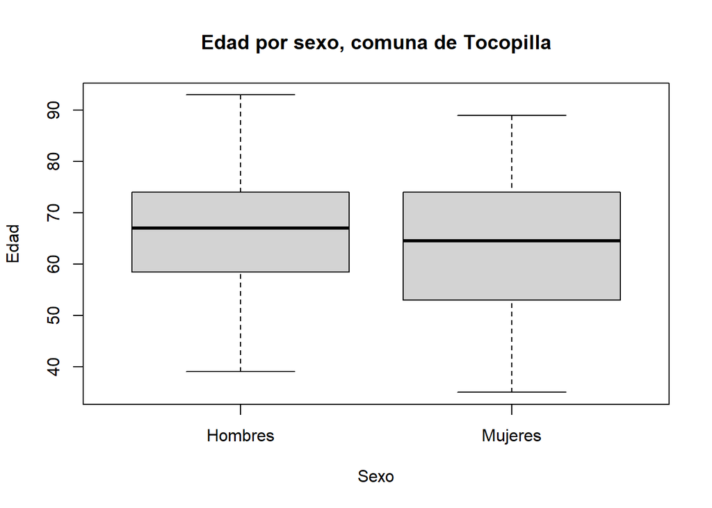